# Two Way Convergence

Tom Booker

07/05/2021

## Two Way Convergence

We’re interested in quantifying the extent of convergence between pairs of species in the CoAdapTree project.

We have 3 potential approaches for analysing 2-way convergence:

1. The Null-Z test (the Null-W test, but with WZA scores) (**asymmetric**)
2. A pMax style approach, what is the larger of the two p-values, is that smaller than you’d expect based on order statistic thinking (**symmetric**)
3. A contingency table approach, where you ask if the proportion of overlapping hits between two species is larger than you’d expect by chance (**symmetric**)

By **symmetric/asymmetric** I’m referring to a test that is dependant on the configuration of species that you put in. The null-W test is **assymetric** because the result depends on which species you put into the test first.

## 2. A pMax style approach

When using the pMax, we’ve been working with order statistics, a useful non-parametric statistical tool.

Under the null hypothesis that there is no adaptation in either of the two species, both p-values can be thought of as random draws from a uniform distribution (e.g. `runif(2)`).

The null distribution for the $k^{th}$ order statistic of $n$ random uniform variables is:

$U(k) \sim Beta(k, n+1-k)$.

So, for two p-values from a pair of species we can use: `pbeta(max(c(p_1, p_2)), shape1 = 2, shape2 = 2 + 1 - 2)`to calculate the probability (p-value) of the observation.

Here are some examples where 1 of the species had a really striking result (p = 0.0001):

```
## [1] 0.0025
```

```
## [1] 0.01
```

```
## [1] 0.04
```

```
## [1] 0.09
```

```
## [1] 0.9801
```

Now, let’s think about doing that across the entire genome. Let’s say for the sake of simplicity that there are 20,000 orthogroups and that they are all 1:1.

Let’s simulate empirical p-values for 20,000 genes

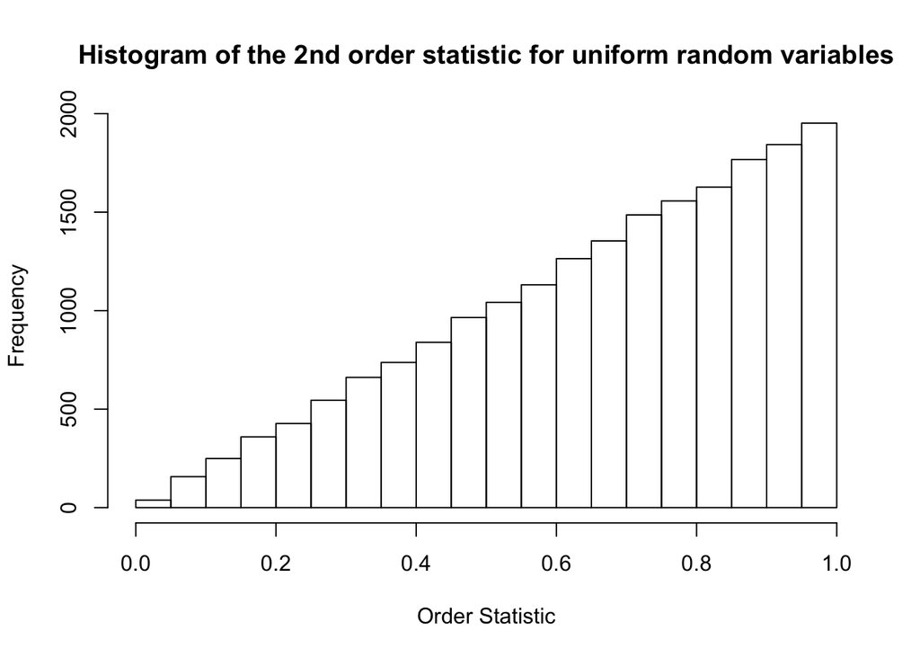

[figure not shown]

```r
## Generate some p-values under the null for two species
twoSpeciesData <- cbind( sample(20000)/20000,
                        sample(20000)/20000)

## Plot the distribution of order stats.
hist(apply(twoSpeciesData, 1,  function(x) max(x)),
     main = "Histogram of the 2nd order statistic for uniform random variables", xlab = "Order Statistic" )
## Plot the null distribution of order stats
hist( rbeta( 20000, shape1 = 2, shape2 = 2 + 1 - 2),
      main = expression("Histogram of Beta distribution with "*alpha*" = 2, "*beta*" = 2"),
      xlab = "Order Statistic")
```

I’d say those look pretty similar, that’s a good sanity check.

Now let’s calculate the p-values from our order stats and plot those (we expect a nuce uniform distribution)

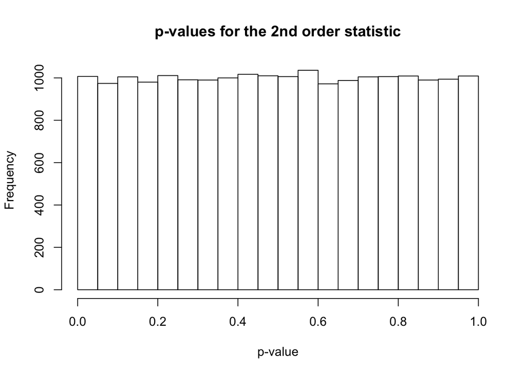

```r
pValues <- apply(twoSpeciesData, 1,  function(x) pbeta(max(x), shape1 = 2, shape2 = 2 + 1 - 2))
hist( pValues,
      main = "p-values for the 2nd order statistic",
      xlab = "p-value")
```

Looks good, let’s move on.

How are we going to handle these? We could just look at the number of genes with p less than some value, but there are LOTS of comparisons here so we’ll need to do some kind of FDR correction.

For starters, let’s plot the above distribution as q-values instead of p-values:

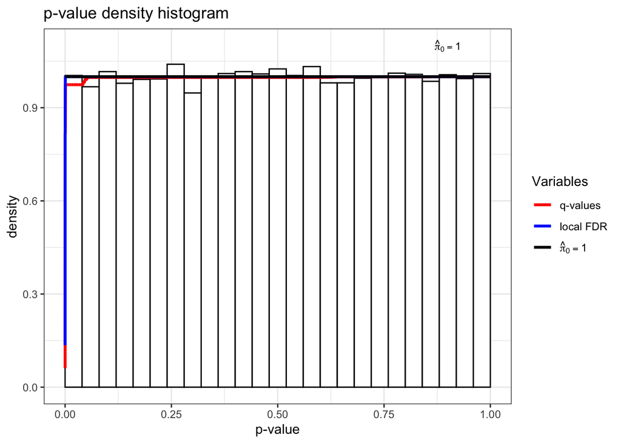

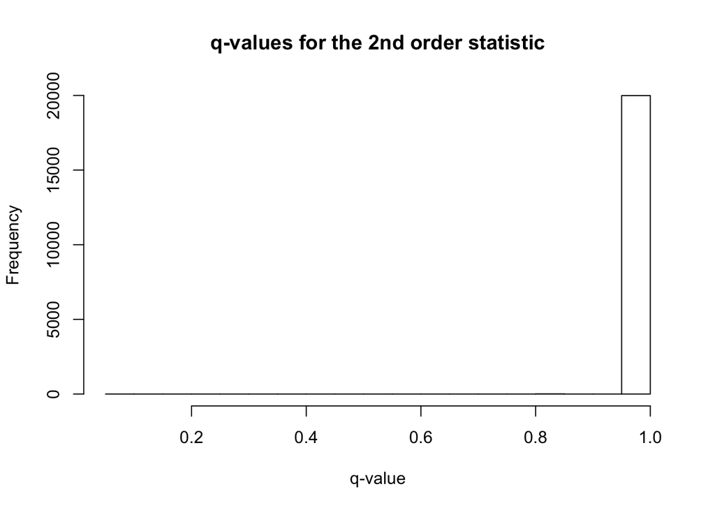

```r
library( qvalue ) ## Use the q-value package
qValues <- qvalue(pValues)

hist( qValues)
hist( qValues$qvalues,
      main = "q-values for the 2nd order statistic",
      xlab = "q-value")
```

Groovy.

The q-values from the order stats are well behaved and conform to the null expectation.

Mike suggested a neat way to calculate the number of genes with convergence using the q-values. The q-value is an estimate of the probability that the null is true. That’s why you see a lot of numbers piling up close to 1 in this null dataset. If you take the complement of a q-value you have the probability that the null is false. So across the genome, if we take `sum( 1 - q_value )` we have an estiamte of how many genes have false nulls. Let’s take a look at that in practice.

For the above dataset we have

```r
sum(1-qValues$qvalues)
```

```
## [1] 60.07066
```

Ok, so what does this look like after a bunch of random trials? Let’s repeat the above 1000 times and plot the results

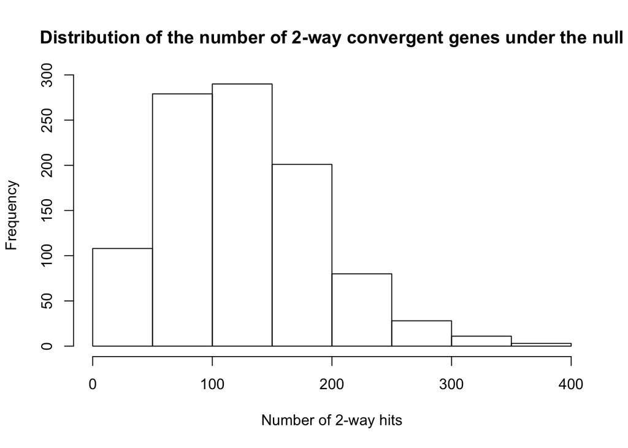

```r
nullGenomeSimulator_pMax <- function( nGenes = 20000 ){
    twoSpeciesData <- cbind( sample(nGenes)/nGenes,
                              sample(nGenes)/nGenes)

    pValues <- apply(twoSpeciesData, 1,  function(x) pbeta(max(x), shape1 = 2, shape2 = 2 + 1 - 2))

    qValues <- qvalue(pValues)

    sum(1-qValues$qvalues)
}

null_pMax <- replicate( 1000, nullGenomeSimulator_pMax() )

hist( null_pMax ,
          main = "Distribution of the number of 2-way convergent genes under the null",
      xlab = "Number of 2-way hits")
```

```r
# Mean
mean(null_pMax)
```

```
## [1] 125.2863
```

```r
# Median
median(null_pMax)
```

```
## [1] 116.5159
```

```r
# Quantiles
quantile(null_pMax)
```

```
##         0%        25%        50%        75%       100%
##   1.833601  79.910589 116.515867 167.568488 364.267024
```

```r
# 95th Percentile
quantile(null_pMax, 0.95)
```

```
##      95%
## 243.1706
```

### pMax approach when there are false nulls

I guess that we’ll have the same issue with this 2-species pMax approach where a strongly significant hit in onw species can make it look like there’s convergence.

First let’s define some functions:

```r
## Simulate correlations under
simulateCorrelation_empirical <- function(r, n = 100, genes = 20000){
  # r is the population correlation coefficient
  # x1 is the sample data
  x1 = rnorm(n)
  # x2 is the data that will be transformed so as to be correlated with x1
  x2 = rnorm(n)

  Y = r*x1+sqrt(1-r*r)*x2
  empricial_p <- rank( c( cor.test(Y, x1)$p.value, runif(genes-1) ) )[1]/genes
  return( empricial_p )
}

## Now make the function run in a vectorised fashion
simulateCorrelationVectorized_empirical <- Vectorize(simulateCorrelation_empirical)

# Here's a function to simulate GEA data for X species
simulateMultipleGEAs <- function(corVector, times, empirical = F){
  # t is for transpose
  if (empirical==F){
      t(replicate(times,  simulateCorrelationVectorized_parametric(corVector, n = 40) )  )
  }
  else if (empirical == T){
          t(replicate(times,  simulateCorrelationVectorized_empirical(corVector, n = 40) )  )
  }
}
```

Now let’s plot the p-value distribution when some number of genes have false nulls

```r
## For example, here is a set of pValues for 10 genes where 1 species has a false null and the other is true
simulateMultipleGEAs(c(0.4, 0.0), # This is the vector of true correlation coefficients
                     10,  # This is the number of genes
                     empirical = T) # This tells the function to give empirical P-values
```

```
##          [,1]    [,2]
##  [1,] 0.00175 0.46985
##  [2,] 0.00040 0.86050
##  [3,] 0.04775 0.94410
##  [4,] 0.00770 0.20545
##  [5,] 0.00375 0.47985
##  [6,] 0.01365 0.65935
##  [7,] 0.00095 0.73305
##  [8,] 0.02360 0.07265
##  [9,] 0.05840 0.42440
## [10,] 0.00095 0.15265
```

Let’s now do that for 20000 genes and apply the pMax procedure

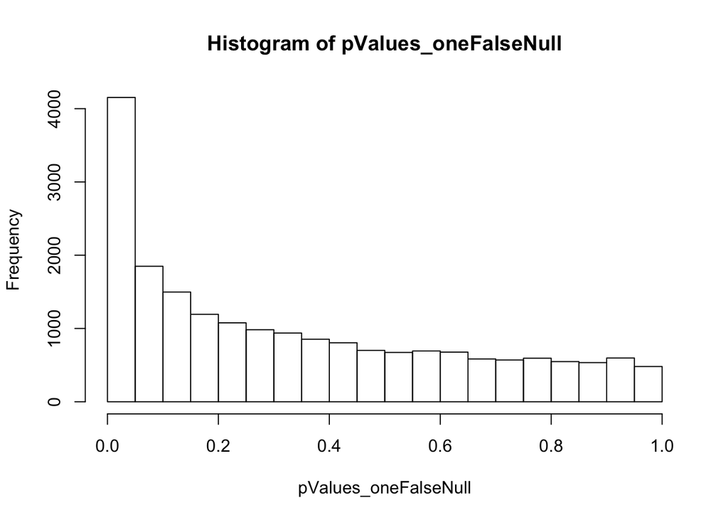

```r
oneFalseNull <- simulateMultipleGEAs(c(0.4, 0.0), 20000, empirical = T)


pValues_oneFalseNull <- apply(oneFalseNull, 1,  function(x) pbeta(max(x), shape1 = 2, shape2 = 2 + 1 - 2))

hist(pValues_oneFalseNull)
```

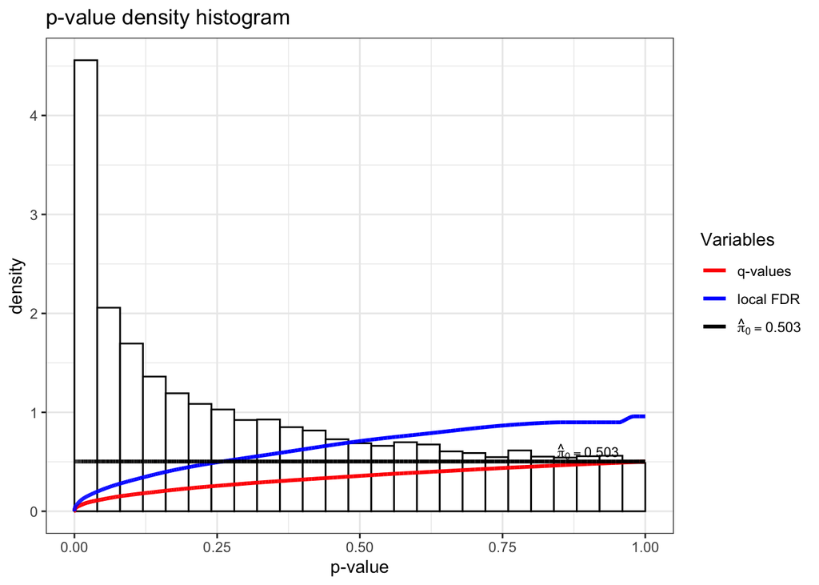

```r
qValues_oneFalseNull <- qvalue(pValues_oneFalseNull)

hist(qValues_oneFalseNull)
```

```r
sum(1-qValues_oneFalseNull$qvalues)
```

```
## [1] 14769.22
```

Pretty fudged up by the one-way hits.

Now I’ll do a case with 2 false nulls for 1000 genes and true nulls for the rest

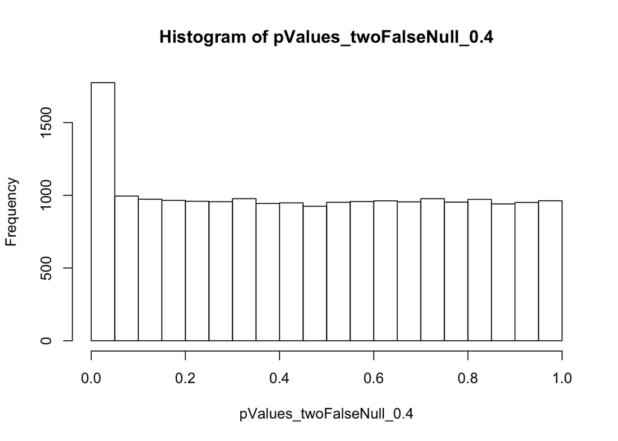

```r
twoFalseNull_0.4_hits <- simulateMultipleGEAs(c(0.4, 0.4), 1000, empirical = T)

twoFalseNull_0.4_misses <- cbind( sample(20000, 19000)/20000,
                              sample(20000, 19000)/20000)

twoFalseNull_0.4 <- rbind( twoFalseNull_0.4_hits,
                           twoFalseNull_0.4_misses)

pValues_twoFalseNull_0.4 <- apply(twoFalseNull_0.4, 1,  function(x) pbeta(max(x), shape1 = 2, shape2 = 2 + 1 - 2))

hist(pValues_twoFalseNull_0.4)
```

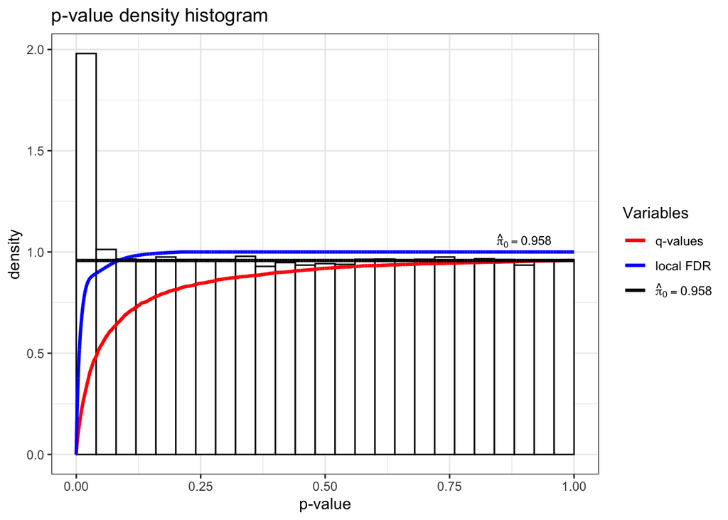

```r
qValues_twoFalseNull_0.4 <- qvalue(pValues_twoFalseNull_0.4)

hist(qValues_twoFalseNull_0.4)
```

```r
sum(1-qValues_twoFalseNull_0.4$qvalues)
```

```
## [1] 3456.999
```

```r
sum(1-qValues_twoFalseNull_0.4$qvalues)
```

```
## [1] 3456.999
```